# R Notebook

## Weekend Homework - stats

```r
library(tidyverse)
library(janitor)
library(infer)
library(e1071)
library(modelr)
```

```r
players <- read_csv("data/players.csv")
players <- clean_names(players)
```

1. The overall variable is of primary interest to the NFA. Perform a full analysis of the distribution of the overall variable in the sample. Use the tools you learned this week to quantify centrality, spread, modality and normality of this variable, making an appropriate choice of metric for each.

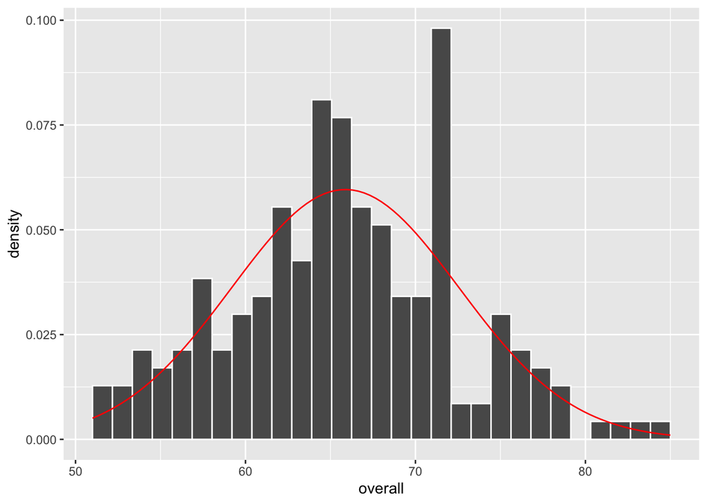

```r
players %>%
  ggplot +
  aes(x = overall) +
  geom_histogram(aes(y = ..density..), col = "white") +
  stat_function(
    fun = dnorm,
    args = list(
      mean = mean(players$overall),
      sd = sd(players$overall)
    ),
    col = "red")
```

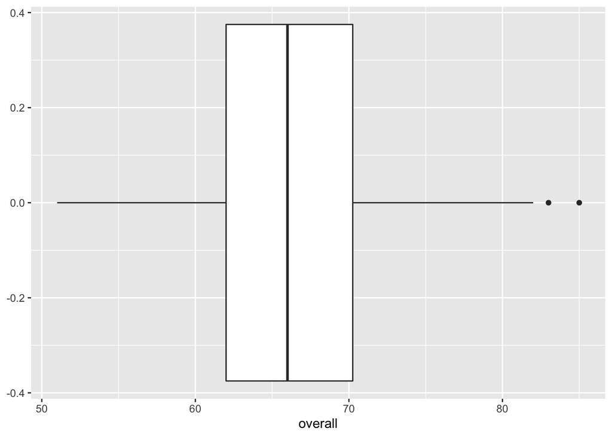

```r
players %>%
  ggplot +
  aes(y = overall) +
  geom_boxplot() +
  coord_flip()
```

```r
library(skimr)

players %>%
  select(overall) %>%
  skim()
```

Data summary

| Name | Piped data |
| --- | --- |
| Number of rows | 200 |
| Number of columns | 1 |
| _______________________ |  |
| Column type frequency: |  |
| numeric | 1 |
| ________________________ |  |
| Group variables | None |

**Variable type: numeric**

| skim_variable | n_missing | complete_rate | mean | sd | p0 | p25 | p50 | p75 | p100 | hist |
| --- | --- | --- | --- | --- | --- | --- | --- | --- | --- | --- |
| overall | 0 | 1 | 65.88 | 6.69 | 51 | 62 | 66 | 70.25 | 85 | ▂▆▇▃▁ |

The mean and the median of the data are v close - suggesting that the data are fairly symmetrical

From these first plots, and the 5 number summary, it appears that the distribution has some outliers to the right - will try to check if this has an impact on the distribution, checking it isn’t right skewed

```r
skewness(players$overall)
```

```
## [1] 0.08664496
```

```r
#so the data are fairly symmetrical according to this measure - don't need to worry about the skew
```

What about modality?

```r
#I'll use the getMode function from the other day

#will have to create it in scope first

getMode <- function(data){
  tabled_data <- table(data)
  table_names <- names(tabled_data)
  return( table_names[tabled_data == max(tabled_data)] )
}

players %>%
  summarise(mode = getMode(overall))
```

| mode |
| --- |
| 66 |

```r
# so  mean median and mode are all 66 to 0 dps
```

Now check the normality of the data - do so by using bootstrapping

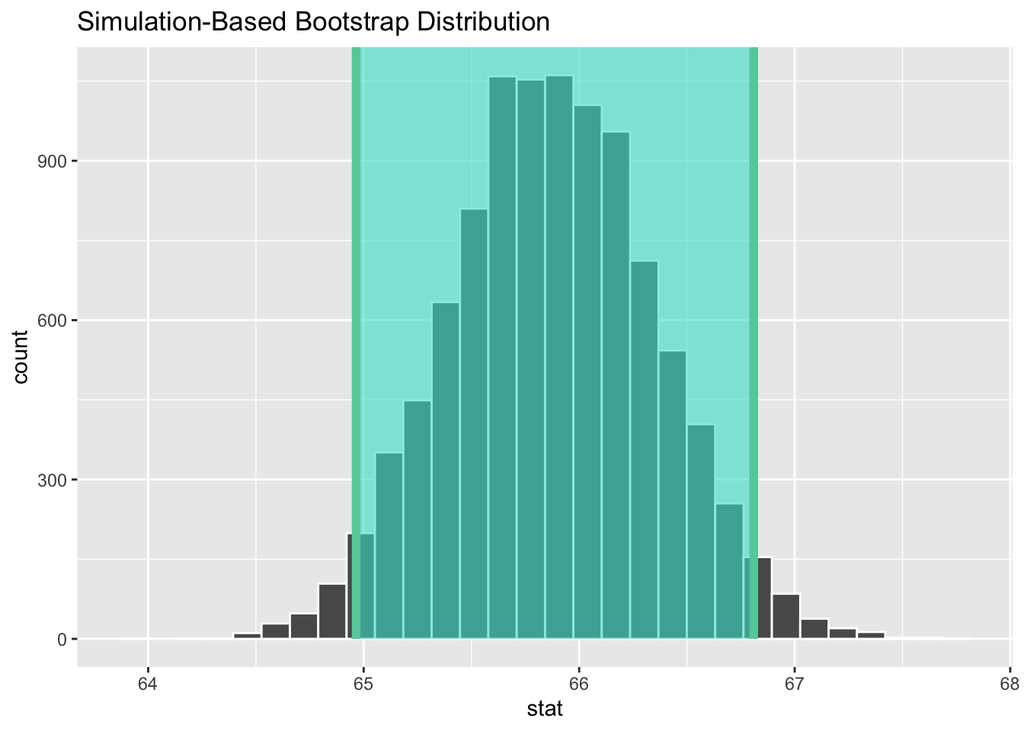

```r
bootstrap_overall <- players %>%
  specify(response = overall) %>%
  generate(reps = 10000, type = "bootstrap") %>%
  calculate(stat = "mean")

bootstrap_overall_ci95 <- bootstrap_overall %>%
  get_ci(level = 0.95, type = "percentile")

bootstrap_overall %>%
  visualise(bins = 30) +
  shade_ci(endpoints = bootstrap_overall_ci95)
```

```r
bootstrap_overall_ci95
```

| 2.5% | 97.5% |
| --- | --- |
| 64.965 | 66.81 |

The NFA have asked SoccerIntel to tell them which of the playing style metrics is most strongly correlated with overall rating, so they can tell individual clubs which component of playing style to focus on in their training regimes. Calculate these correlations and make a recommendation.

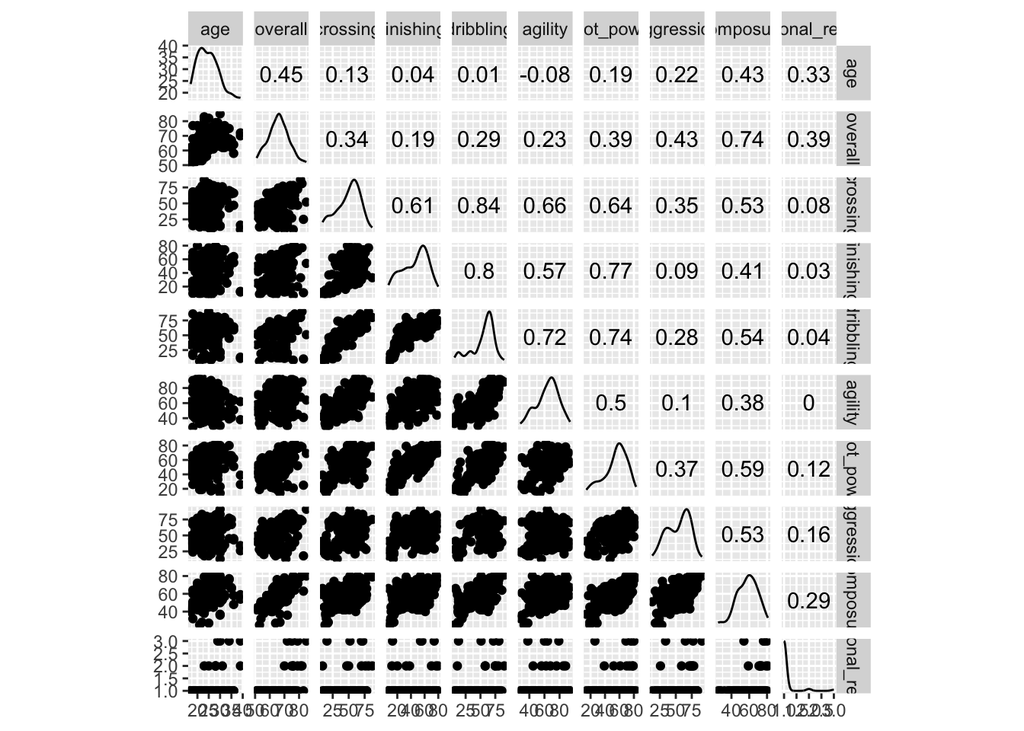

```r
library(GGally)
players %>%
  ggscatmat()
```

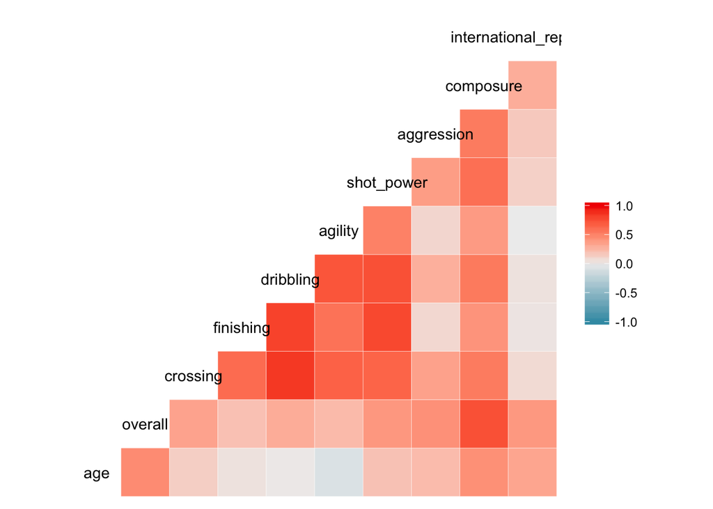

```r
players %>%
  ggcorr()
```

Strongest correlation is between overall and composure: 0.74

SoccerIntel want to properly detail the relationship between the most strongly correlated playing style metric from above (hereafter, we’ll just call this the ‘style metric’) with the overall rating. Perform simple linear regression to quantify the relationship. If the clubs manage to raise the style metric by 5 points on average by improvement in training, how would you expect the overall rating to change? Can you provide a range of likely values for this slope?

```r
library(broom)
style_model <- lm(formula = overall ~ composure, data = players)

summary(style_model)
```

```
##
## Call:
## lm(formula = overall ~ composure, data = players)
##
## Residuals:
##     Min      1Q  Median      3Q     Max
## -8.8076 -2.9324 -0.3853  2.6210 16.0888
##
## Coefficients:
##             Estimate Std. Error t value Pr(>|t|)
## (Intercept) 39.80442    1.71942   23.15   <2e-16 ***
## composure    0.44741    0.02899   15.43   <2e-16 ***
## ---
## Signif. codes:  0 '***' 0.001 '**' 0.01 '*' 0.05 '.' 0.1 ' ' 1
##
## Residual standard error: 4.521 on 198 degrees of freedom
## Multiple R-squared:  0.546,  Adjusted R-squared:  0.5437
## F-statistic: 238.1 on 1 and 198 DF,  p-value: < 2.2e-16
```

```r
glance(style_model)
```

| r.squared | adj.r.squared | sigma | statistic | p.value | df | logLik | AIC | BIC | deviance | df.residual |
| --- | --- | --- | --- | --- | --- | --- | --- | --- | --- | --- |
| 0.5460099 | 0.543717 | 4.521397 | 238.1328 | 8.516632e-36 | 2 | -584.5469 | 1175.094 | 1184.989 | 4047.719 | 198 |

```r
tidy_style_model <- clean_names(tidy(style_model))

tidy_style_model
```

| term | estimate | std_error | statistic | p_value |
| --- | --- | --- | --- | --- |
| (Intercept) | 39.8044234 | 1.71941838 | 23.14993 | 3.098814e-58 |
| composure | 0.4474099 | 0.02899319 | 15.43155 | 8.516632e-36 |

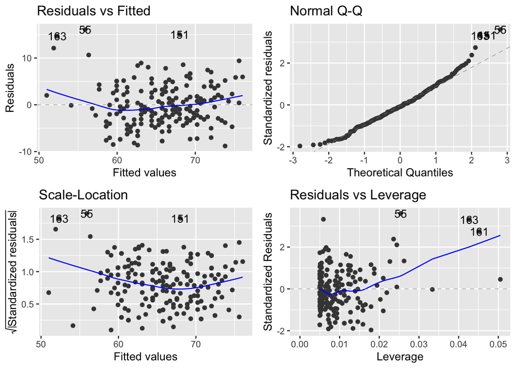

```r
library(ggfortify)

autoplot(style_model)
```

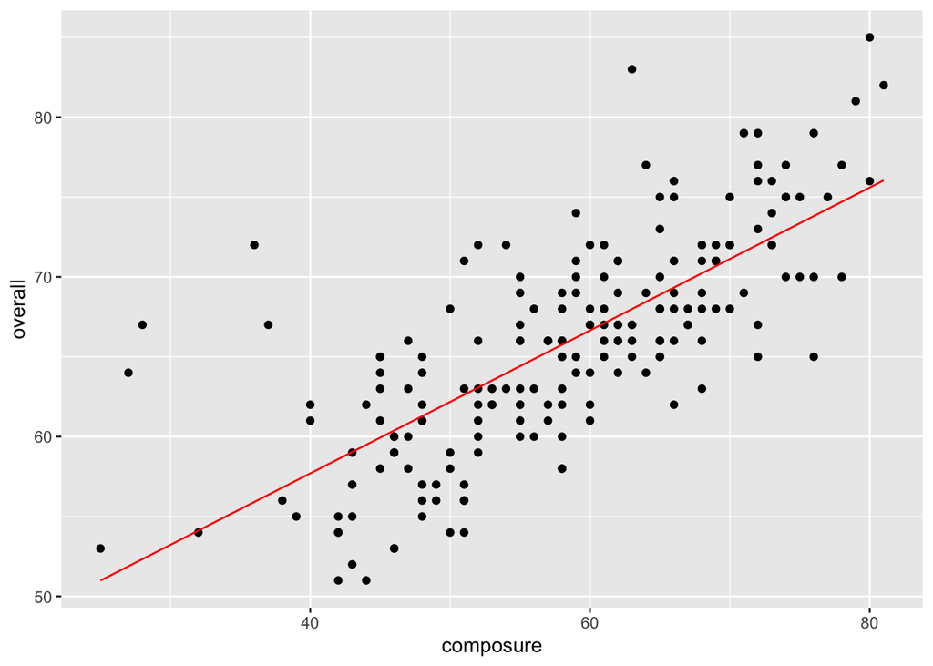

```r
players %>%
  add_predictions(style_model) %>%
  ggplot +
    aes(x = composure) +
  geom_point(aes(y = overall)) +
  geom_line(aes(y = pred), col = "red")
```

Try to fit a linear model by bootstrapping

```r
bootstrap_style_slope <- players %>%
  specify(formula = overall ~ composure) %>%
  generate(reps = 10000, type = "bootstrap") %>%
  calculate(stat = "slope")

slope_ci95 <- bootstrap_style_slope %>%
  get_ci(level = 0.95, type = "percentile")


slope_ci95
```

| 2.5% | 97.5% |
| --- | --- |
| 0.3723409 | 0.5259762 |

```r
# an increase in 5 percent in the composure measure would result in a change of

outcome <- 5 * tidy_style_model$estimate
outcome
```

```
## [1] 199.02212   2.23705
```

```r
# 2.23705 % overall rating - though
```

The NFA would like to know the proportion of players in the country who are ‘internationally significant’ (defined as having an international_reputation greater than 1). Determine this proportion for the country, with a suitable measure of uncertainty in the estimate.

```r
int_significant_players <- players %>%
  mutate(int_significant =  international_reputation > 1)

int_significant_players <- int_significant_players %>%
  mutate(int_significant = as.numeric(int_significant))


int_significant_players
```

| age | overall | crossing | finishing | dribbling | agility | shot_power | aggression | composure | international_reputation | height | weight | preferred_foot | value | wage | release_clause | int_significant |
| --- | --- | --- | --- | --- | --- | --- | --- | --- | --- | --- | --- | --- | --- | --- | --- | --- |
| 25 | 72 | 60 | 48 | 69 | 83 | 68 | 62 | 73 | 1 | 5'9 | 146lbs | Right | €3.7M | €4K | €6.1M | 0 |
| 27 | 65 | 59 | 59 | 64 | 82 | 63 | 69 | 59 | 1 | 5'10 | 157lbs | Right | €575K | €2K | €719K | 0 |
| 26 | 75 | 67 | 49 | 71 | 74 | 62 | 78 | 70 | 1 | 5'6 | 161lbs | Right | €6.5M | €50K | €12.8M | 0 |
| 28 | 76 | 64 | 78 | 73 | 44 | 70 | 82 | 80 | 1 | 5'11 | 157lbs | Right | €8M | €29K | €16.8M | 0 |
| 30 | 68 | 68 | 33 | 55 | 59 | 62 | 71 | 50 | 1 | 6'2 | 179lbs | Left | €675K | €4K | €1.1M | 0 |
| 30 | 67 | 15 | 15 | 22 | 54 | 14 | 41 | 37 | 1 | 6'4 | 172lbs | Right | €575K | €2K | €1.3M | 0 |
| 22 | 66 | 66 | 25 | 55 | 66 | 26 | 58 | 52 | 1 | 5'9 | 154lbs | Right | €850K | €7K | €2M | 0 |
| 23 | 65 | 54 | 59 | 66 | 85 | 49 | 58 | 65 | 1 | 5'7 | 139lbs | Right | €750K | €4K | NA | 0 |
| 36 | 64 | 47 | 64 | 59 | 51 | 62 | 43 | 48 | 1 | 6'0 | 174lbs | Right | €160K | €1K | €216K | 0 |
| 24 | 56 | 38 | 54 | 50 | 44 | 55 | 36 | 51 | 1 | 5'10 | 157lbs | Right | €130K | €1K | €228K | 0 |

[output cut: 190 more lines]

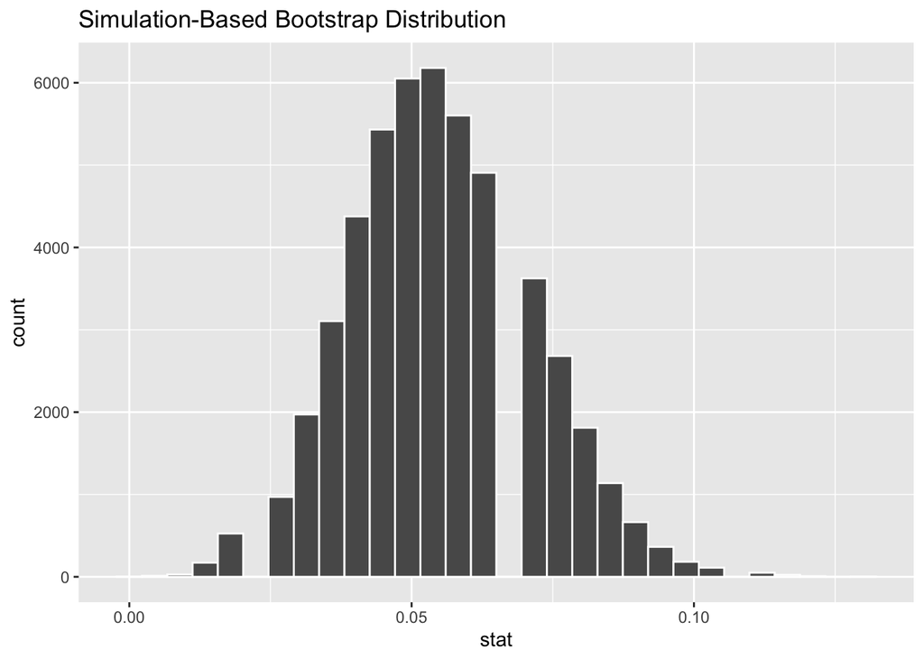

```r
#Now that binary int_significant variable is there - need to get an estimate


#remember bootstrapping workflow from infer(): specify(), generate(), calculate()

bootstrap_int_significant <- int_significant_players %>%
  specify(response = int_significant) %>%
  generate(reps = 50000, type =  "bootstrap") %>%
  calculate(stat = "mean")

bootstrap_int_significant %>%
  visualise(bins = 30)
```

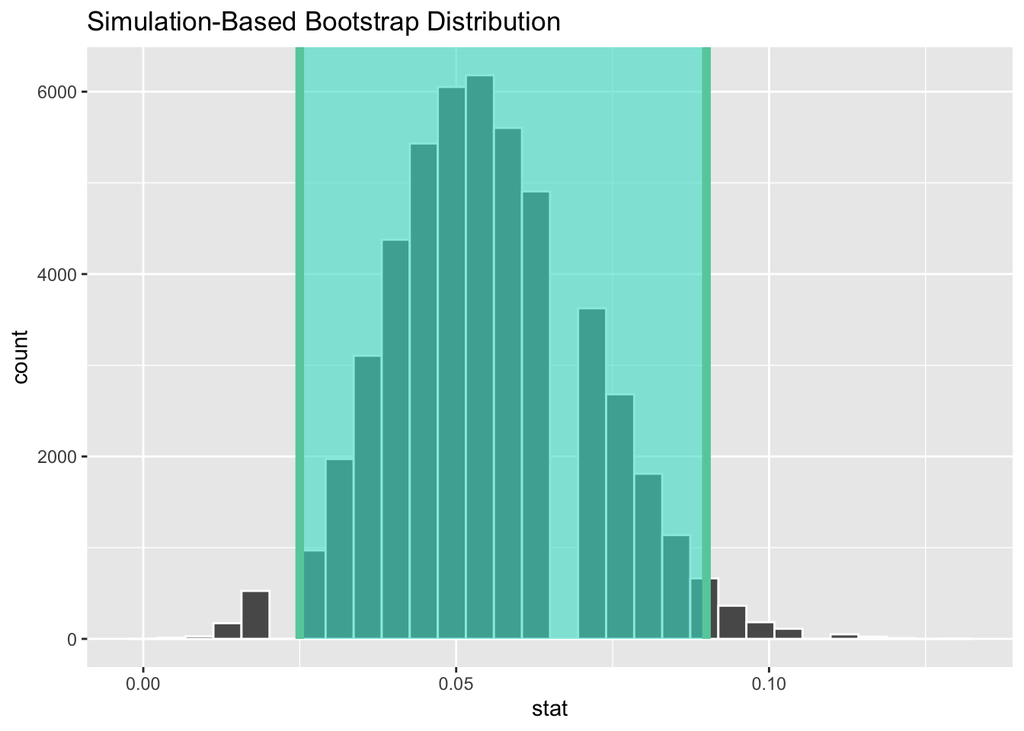

```r
ci_95 <- bootstrap_int_significant %>%
  get_ci(level = 0.95, type = "percentile")

bootstrap_int_significant %>%
  visualise(bins = 30) +
  shade_ci(ci_95)
```

```r
ci_95
```

| 2.5% | 97.5% |
| --- | --- |
| 0.025 | 0.09 |

```r
point_est_mean_int_sig <- bootstrap_int_significant %>%
  summarise(mean(stat))

point_est_mean_int_sig
```

| mean(stat) |
| --- |
| 0.0550618 |

```r
ci_95
```

| 2.5% | 97.5% |
| --- | --- |
| 0.025 | 0.09 |

SoccerIntel let you know that the NFA are keen to highlight an ‘increase in the proportion of internationally significant players in the country’ in a forthcoming media release. Last year’s proportion was 0.04. Do you think this optimistic appraisal is statistically justifiable?

```r
  #alpha: 0.95


  #H0: Proportion of int_significant players is at 0.04 or less

      #proportion <= 0.04

  #HA: proportion > 0.04
```

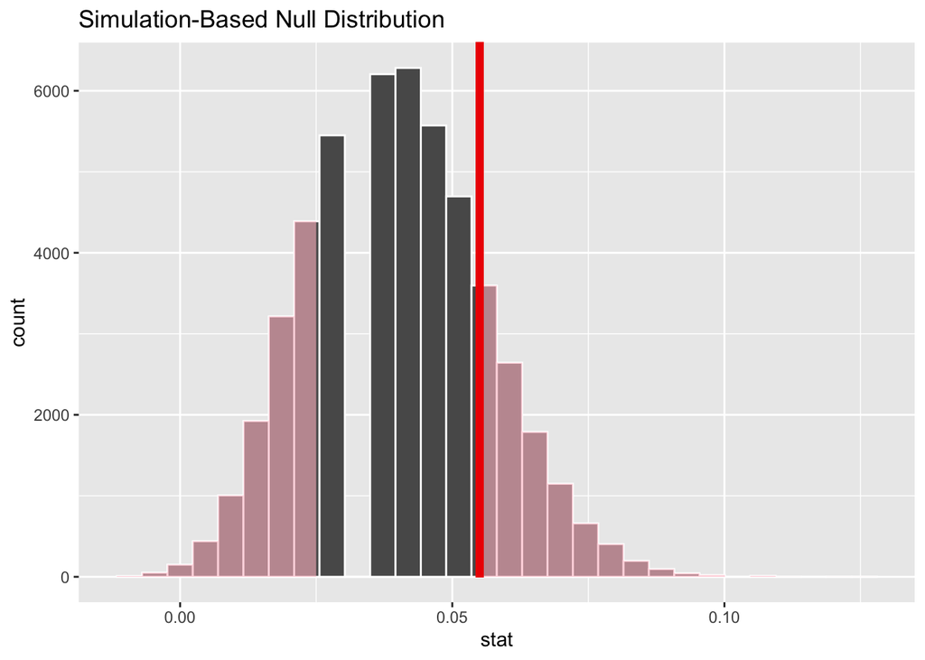

```r
#assuming null hypothesis: caluculate null distribution

null_distribution <- int_significant_players %>%
  specify(response = int_significant) %>%
  hypothesize(null = "point", mu = 0.04) %>%
  generate(reps = 50000, type = "bootstrap") %>%
  calculate(stat = "mean")

null_distribution %>%
  visualise(bins = 30) +
  shade_p_value(obs_stat = point_est_mean_int_sig$`mean(stat)`, direction = "both")
```

```r
null_distribution %>%
  get_p_value(obs_stat = point_est_mean_int_sig$`mean(stat)`, direction = "both")
```

| p_value |
| --- |
| 0.28064 |

```r
#p value > 0.05 so we fail to reject the null hypothesis of no change/ fall in prop of int_significant players
```

SoccerIntel let you know that the NFA are keen to highlight an ‘increase in the proportion of internationally significant players in the country’ in a forthcoming media release. Last year’s proportion was 0.04. Do you think this optimistic appraisal is statistically justifiable?

No - the optimistic appraisal is not justified.